# Lab_2_Davidovich_Nitzan_and_Strano_Nechama

2022-06-13

Reading the HTML as text

# *Part1*

## **Question 1**

### *a*

Load the complete `Moby dick` book from the [Gutenberg project](https://www.gutenberg.org) into `R`. The book is available [here](https://www.gutenberg.org/files/2701/2701-h/2701-h.htm). Extract the text from the html as a long string, and print the first line of the text in the file (starting with `The Project Gutenberg ...`)

```r
book <- webpage %>% html_nodes("div") %>% html_text()
book[1]
```

```
## [1] "The Project Gutenberg eBook of Moby-Dick; or The Whale, by Herman Melville"
```

### *b*

Split the text string into words, separated by spaces, commas (`,`), periods (`.`), and new line characters (`\n` and `\r`). How many words are there? Compute the distribution of lengths of words you got.

```r
all_words_html <- webpage %>% html_text() %>% str_split(",|\\.|[:space:]")
all_words_html <- all_words_html[[1]]
words <- all_words_html[all_words_html!=""]
print(length(words))
```

```
## [1] 217192
```

Computing the distribution of lengths of words you got, and plot using a bar-plot and computing the `median`, `mean`, `longest` and `most common` word lengths.

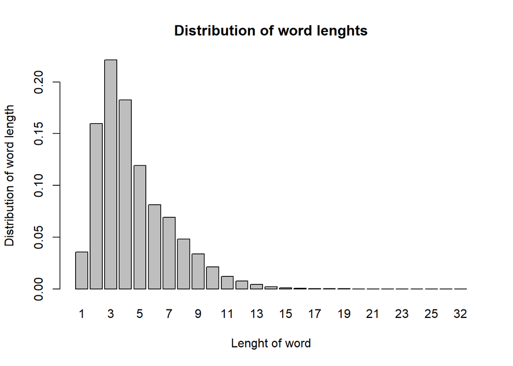

```r
len_words <- str_length(words)
words_dist<- table(len_words)/length(words)
barplot(words_dist, main = "Distribution of word lenghts", xlab = "Lenght of word", ylab = "Distribution of word length")
```

```r
#median
median(len_words)
```

```
## [1] 4
```

```r
#mean
mean(len_words)
```

```
## [1] 4.56102
```

```r
#longest
max(len_words)
```

```
## [1] 32
```

```r
#most common
sort(table(words), decreasing = TRUE)[1]
```

```
##   the
## 13864
```

### *c*

Count the words frequencies in the text - i.e. the number of times each unique word appears in the text. Show the top 10 most frequent words with their frequencies. Is the list of top words surprising? explain.

```r
sort(table(words), decreasing = TRUE)[1:10]
```

```
## words
##   the    of   and    to     a    in  that   his    it     I
## 13864  6669  6067  4579  4550  3958  2831  2456  1955  1834
```

It makes sense that these are the 10 most frequent words because they are the most common words in English - the conjunction words. And also they have the vowels in them which are more common then other letters.

## **Question 2**

### *a*

Split the book text into `chapters`, such that you obtain an array of strings, one per chapter. Count and plot the number of words per each chapter (y-axis) vs. the chapter index (1,2,3.., on x-axis). each chapter is splitted to word in the same manner as in Qu. 1

We scraped the html and made sure to separate and clean up each chapter and include the etymology and epilogue. Then we computed the number of words in each of the given chapters and plotted to see the scattering of the different words throughout the chapters.

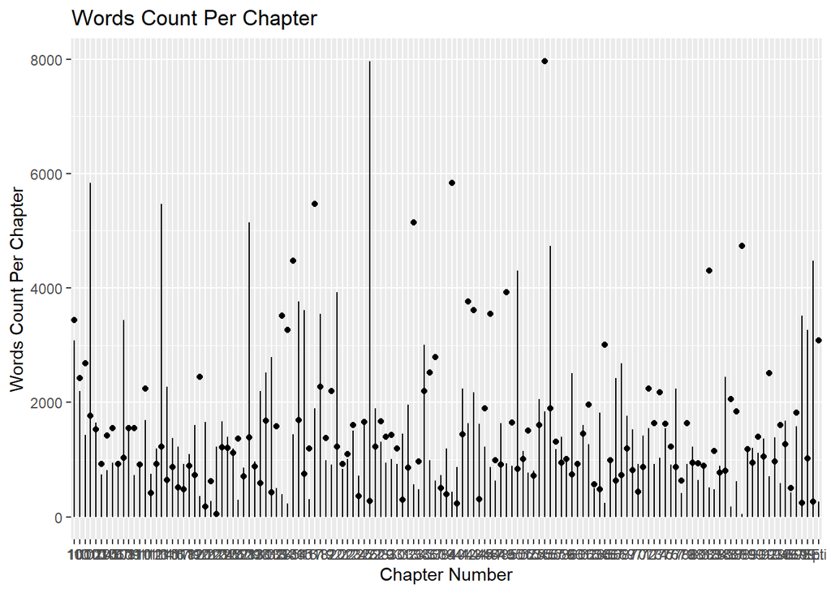

```r
webpage <- read_html("https://www.gutenberg.org/files/2701/2701-h/2701-h.htm#link2HCH0004")
moby_lines <- html_text2(html_nodes(webpage, 'title,p,h1,h2,h3'))
mobybook <- paste(moby_lines, collapse = " ")

chapters = strsplit(mobybook,"\r \r \r \r \r ")

#etymology =
chapters[[1]][1] <-  sub(".*\r \r ETYMOLOGY.\r \r","",chapters[[1]][1])
chapters = chapters[[1]][1:137]

#Counting words per chapter
word_amount = function(chapters){
  vec_words=vector(length=length(chapters))
  for (i in 1:length(chapters)){
    all_words_c <- chapters[i] %>% str_split(",|\\.|[:space:]")
    all_words_c = lapply(all_words_c,function(z){z[!is.na(z) & z != ""]})
    vec_words[i] = length(all_words_c[[1]])
  }
return(vec_words)
}

#X-is vector
num_word <- word_amount(chapters)
chapter_index = c(1:137)
chapter_index[1] = "Eti"
chapter_index[137] = "Epi"

#plotting
data.frame(num_word) %>%
ggplot(aes(x=chapter_index, y=num_word)) +
  geom_point() +
  geom_segment( aes(x=c(1:137), xend=c(1:137), y=0, yend=num_word))+
  labs(x="Chapter Number",y= "Words Count Per Chapter",fill=c(1:137),title = "Words Count Per Chapter")
```

### *b*

Write a function that receives as input a query word, and an array of strings representing the chapters. The function returns a vector of the `relative frequencies` of the word in each chapter. Apply the function to the following words `Ahab`, `Moby`, `sea`. Plot for each one of them the trend, i.e. the frequency vs. chapter, with chapters in increasing orders. Do you see a different behavior for the different words? in which parts of the book are they frequent?

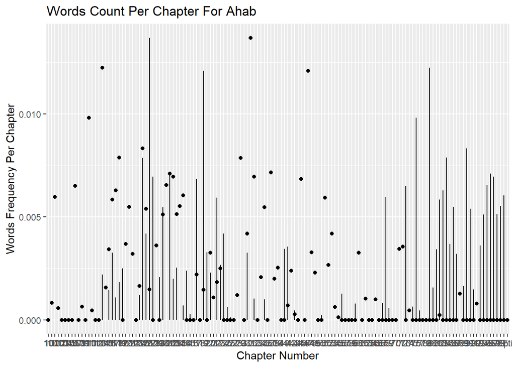

```r
word_frequencies = function(word,chapters){
  freq_vec = c()
  for (i in 1:length(chapters)){
    all_words_c <- chapters[i] %>% str_split(",|\\.|[:space:]")
    all_words_c <- all_words_c[[1]]
    words_c <- all_words_c[all_words_c!=""]
    total_words_chap = length(words_c)
    word_freq = sort(table(words_c), decreasing = TRUE)
    our_word = as.vector(word_freq[word])
    if (is.na(our_word)){
      freq_vec = c(freq_vec,0)}
    else {
      freq_vec = c(freq_vec,our_word/total_words_chap)}

    }
  return(freq_vec)
}

Ahab_freq <- word_frequencies("Ahab",chapters)
Moby_freq <- word_frequencies("Moby",chapters)
Sea_freq <- word_frequencies("sea",chapters)

# plotting Ahab
data.frame(Ahab_freq) %>%
ggplot(aes(x=chapter_index, y=Ahab_freq)) +
  geom_point() +
  geom_segment( aes(x=c(1:137), xend=c(1:137), y=0, yend=Ahab_freq))+
  labs(x="Chapter Number",y= "Words Frequency Per Chapter",fill=c(1:137),title = "Words Count Per Chapter For Ahab")
```

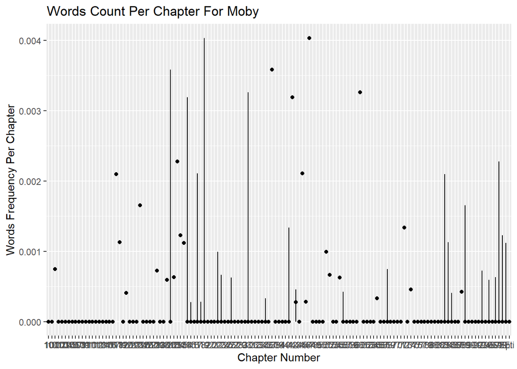

```r
# plotting Moby
data.frame(Moby_freq) %>%
ggplot(aes(x=chapter_index, y=Moby_freq)) +
  geom_point() +
  geom_segment( aes(x=c(1:137), xend=c(1:137), y=0, yend=Moby_freq))+
  labs(x="Chapter Number",y= "Words Frequency Per Chapter",fill=c(1:137),title = "Words Count Per Chapter For Moby")
```

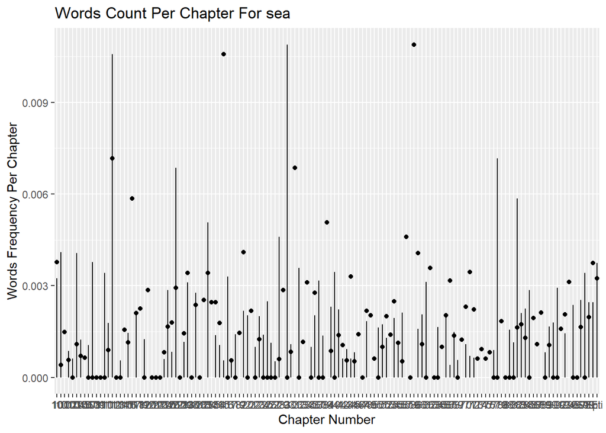

```r
# plotting Sea
data.frame(Sea_freq) %>%
ggplot(aes(x=chapter_index, y=Sea_freq)) +
  geom_point() +
  geom_segment( aes(x=c(1:137), xend=c(1:137), y=0, yend=Sea_freq))+
  labs(x="Chapter Number",y= "Words Frequency Per Chapter",fill=c(1:137),title = "Words Count Per Chapter For sea")
```

The frequency is different between the word’s because each word appears in different part’s of the book at high and low frequency’s. We can see that the word: “Ahab” appears mostly in the middle of the book and towards the end “Moby” appears in the middle at high frequenct’s and at the end at low frequency’s “Sea” seams to apppear through out the whole book at a rather steady frequency asside from a few chapter’s who’s frequency is high.

## **Question 3**

Suppose that Alice and Bob each choose independently and uniformly at random a single word from the book. That is, each of them chooses a random word instance from the book, taking into account that words have different frequencies (i.e. if for example the word `the` appears $1000$ times, and the word `Ishmael` appears only once, then it is $1000$-times more likely to choose the word `the` because each of its instances can be chosen). What is the probability that they will pick the same word? Answer in two ways:

### *a*

*(i)-Formula*

Derive an exact formula for this probability as a function of the words relative frequencies, and compute the resulting value for the word frequencies you got for the book. Because the chance of 2 people choosing the same word is iid the chance is the multiplication of the distribution of the two words (which is the same)
$$P_r(X_A=\omega_i, X_B=\omega_i)= P_r(X_A=\omega_1) P_r(X_B=\omega_1) = {P_r(X=\omega_i)}^2$$
In other words:
$${(frequency(word)/n)}^2$$

*Function - Formula*

We will create a function that computes the probability using the formula:

```r
all_word_freq = table(words)
#this function calculates the probability of choosing the same word with a given frequency table
formula_function = function(all_word_freq){
    all_word_freq <-((all_word_freq)/length(words))^2
  #The probability of choosing the same word from the book:
  return(sum(all_word_freq))
}

formula_function(all_word_freq)
```

```
## [1] 0.008533267
```

*(ii) - Simulation*

Simulate $B=100,000$ times the choice of Alice and Bob and use these simulations to estimate the probability that they chose the same word.

```r
set.seed(1)
simulation_func = function(words){
  B <- 100000
  counter = 0
  for (i in 1:B){
      sample_words <- sample(words,2,replace = TRUE)
    if(sample_words[1] == sample_words[2]){
      counter = counter + 1
  }
  }
  return(counter/B)
}
simulation_func(words)
```

```
## [1] 0.00852
```

Explain your calculations in both ways and compare the results. Are they close to each other? The results are extremely close to each other: (i) 0.008533267 compared to (ii) 0.00852, this is because a simulation works by randomly choosing values, therefore, it is alike to a distribution function and that is why we got very close values.

### *b*

Suppose that instead, we took all **unique** words that appear in the book, and then Alice and Bob would choose each independently and uniformly at random a single word from the list of unique words. What would be the probability that they chose the same word in this case? is it lower, the same, or higher then the probability in (a.)? explain why.

The number of unique words is n, the probability that Alice and Bob will choose the same specific word is
$$1/n∗1/n=1/n^2$$
Because we have n words, the probability that Alice and Bob will chose the same word is
$$n∗1/n^2=1/n$$

```r
unique_words = unique(words)
1/length(unique_words)
```

```
## [1] 3.811993e-05
```

$$0.00003811993$$
is significantly smaller then the probability we got in (a) This is possible and makes sense since in (a) the probability was
$${(frequency(word)/n)}^2$$
which is at least
$$1/n^2$$

## **Question 4**

### *a*

Extract from the book a list of all `five-letter` words. Keep only words that have only English letters. Convert all to lower-case. How many words are you left with? how many unique words? Show the top 10 most frequent five-letter words with their frequencies.

```r
mobybook_clean = str_replace_all(mobybook, "[^a-zA-Z]", " ")
mobybook_clean = tolower(mobybook_clean)

#All words in mobybook
mobybook_split = strsplit(mobybook_clean, " ")
count_letters <- nchar(mobybook_split[[1]] )
#list of all five-letter with duplicates
five_letters <- mobybook_split[[1]][count_letters ==5]

#amount of 5 letter words in the book:
print(length(five_letters))
```

```
## [1] 26513
```

```r
five_unique = unique(five_letters)
#amount of 5 unique letter words in the book:
print(length(five_unique))
```

```
## [1] 1980
```

```r
#top 10 most frequent five-letter words with their frequencies
sort(table(five_letters), decreasing = TRUE)[1:10]
```

```
## five_letters
## whale there which their would other these still about great
##  1226   861   640   616   432   417   403   312   310   307
```

We are left with: * 5 letter words in the book -26513 * 5 unique letter words in the book -1980 * top 10 most frequent five-letter words with their frequencies- whale there which their would other these still about great 1226 861 640 616 432 417 403 312 310 307

### *b*

Compute letter frequencies statistics of the five-letter words: That is, for each of the five locations in the word (first, second,..), how many times each of the English letters `a`, `b`,…,`z` appeared in your (non-unique) list of words. Store the result in a `26-by-5` table and show it as a heat map. Which letter is most common in each location? Do you see a strong effect for the location?

```r
letter_freq <- table(let = unlist(strsplit(five_letters,'')),pos = sequence(nchar(five_letters)))
letter_freq
```

```
##    pos
## let    1    2    3    4    5
##   a 1743 2273 4591 1236   88
##   b 1591  384  245  367  274
##   c 1499  154  185 1699   37
##   d  570   64  417  651 2753
##   e  487 2381 4363 4258 6257
##   f 1304  361  113  244  122
##   g  896  286 1007  338 1111
##   h  967 6527  433  762 1680
##   i  147 2184 3713 1447    5
##   j  181    0    8    0    0
##   k  202   47  208  478  808
##   l  802 1466  628 3785 1040
##   m  764  408  382  274  369
##   n  560  415 1000 2520 1342
##   o  763 3810 2914  521   75
##   p  939  661  181  260  173
##   q  179   24    0    0    0
##   r  718 1824 1763 2904 2541
##   s 3758  119  255 2079 3550
##   t 3660 1724  934 1532 2947
##   u  220  703 2191  511    6
##   v  151  329  600  300    0
##   w 4155  284  188  293  103
##   x    1   25   89    1    6
##   y  251   52   58   11 1221
##   z    5    8   47   42    5
```

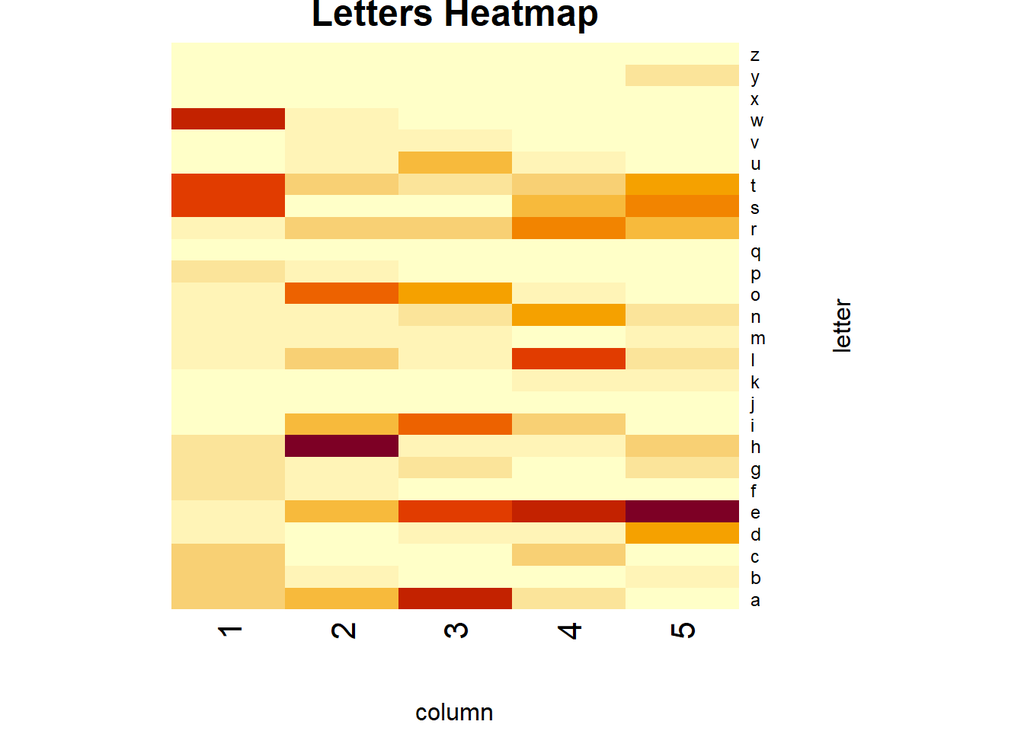

```r
heatmap(letter_freq, Colv = NA, Rowv = NA, scale = "column", xlab = "column", ylab = "letter", main = "Letters Heatmap")
```

We can see that for the- first location:w second location:h third location:a fourth location:e fifth location:e We can see that the fifth and fourth and third position the voul’s appear more often, this is expected since those letter’s appear many times in many word’s.

### *c*

Consider the following random model for typing words: we have a `26-by-5` table of probabilities
$$p_{ij}$$
for i from
$$1$$
to
$$5$$
, and $j$ going over all $26$ possible English letters (assuming lower-case). (This table stores the parameters of the model). Here,
$$p_{ij}$$
is the probability that the $i$-th letter in the word will be the character $j$. Now, each letter $i$ is typed from a categorical distribution over the $26$ letters, with probability $p_{ij}$ of being the character $j$, and the letters are drawn independently for different values of $i$. For example, using
$$p_{5s}=0.3$$
we will draw words such that the probability of the last character being `s` will be $0.3$.
For each five-letter word
$$w$$
, its likelihood under this model is defined simply as the probability of observing this word when drawing a word according to this model, that is, if
$$w=(w_1,w_2,w_3,w_4,w_5)$$
with
$$w_i$$
denoting the $i$-th letter, then
$$Like(w ; p) = \prod_{i=1}^5 p_{i w_i}$$
.
Write a function that receives a `26-by-5` table of probabilities and an array of words (strings), and computes the likelihood of each word according to this model.
Run the function to compute the likelihood of all unique five-letter words from the book, with the frequency table you computed in 4.b. normalized to probabilities. Show the top-10 words with the highest likelihood.

```r
#Creating table of probability's according to each letter
alphabet <- letters[1:26]
letter_freq_un <- table(let = unlist(strsplit(unique(five_letters),'')),pos = sequence(nchar(unique(five_letters))))
letter_freq_un2 = letter_freq_un/(length(unique(five_letters)))

#help function in order to multiply a vector
multiply <- function(vec){
    out <- 1
    for(i in 1:length(vec)){
         out <- out*vec[i]
    }
    out
}

probabilities = function(tablegiven,array) {
  vec_prob_let <- c()
  final_pro <- c()
  for (word in array){
    for (j in 1:5){
      letter = substr(word,j,j)
      index_row<- match(letter,alphabet)
      pij<- letter_freq_un2[index_row,j]
      vec_prob_let<- c(vec_prob_let,pij)

    }
  probability <- multiply(vec_prob_let)
  final_pro <- c(final_pro,probability)

  }
freq_prb_table = as.table(setNames(final_pro,array))
return (freq_prb_table)

}

frequency_five = probabilities(letter_freq_un2,unique(five_letters))
sort(frequency_five, decreasing = TRUE)[1:10]
```

```
##        ebook        whale        bosom        astir        going        merry
## 1.755365e-08 7.192423e-14 1.854276e-20 6.877080e-28 5.862862e-34 1.227632e-39
##        shore        enter        stubb        queen
## 8.551453e-45 2.130211e-51 1.866102e-59 7.307749e-66
```

```r
letter_freq_un <- table(let = unlist(strsplit(unique(five_letters),'')),pos = sequence(nchar(unique(five_letters))))
letter_freq_un2 = letter_freq_un/(length(unique(five_letters)))

letter_freq_un2
```

```
##    pos
## let            1            2            3            4            5
##   a 0.0550505051 0.1666666667 0.1323232323 0.0550505051 0.0161616162
##   b 0.0787878788 0.0055555556 0.0151515152 0.0085858586 0.0035353535
##   c 0.0823232323 0.0111111111 0.0242424242 0.0464646465 0.0065656566
##   d 0.0414141414 0.0085858586 0.0297979798 0.0363636364 0.0818181818
##   e 0.0227272727 0.1020202020 0.0893939394 0.2045454545 0.1383838384
##   f 0.0601010101 0.0040404040 0.0101010101 0.0146464646 0.0095959596
##   g 0.0459595960 0.0035353535 0.0282828283 0.0303030303 0.0156565657
##   h 0.0464646465 0.0560606061 0.0025252525 0.0095959596 0.0454545455
##   i 0.0106060606 0.1035353535 0.1085858586 0.0454545455 0.0020202020
##   j 0.0151515152 0.0000000000 0.0010101010 0.0000000000 0.0000000000
##   k 0.0090909091 0.0025252525 0.0141414141 0.0469696970 0.0333333333
##   l 0.0454545455 0.0777777778 0.0601010101 0.0823232323 0.0419191919
##   m 0.0469696970 0.0111111111 0.0202020202 0.0242424242 0.0131313131
##   n 0.0161616162 0.0237373737 0.0676767677 0.0732323232 0.0464646465
##   o 0.0176767677 0.1489898990 0.0994949495 0.0419191919 0.0111111111
##   p 0.0636363636 0.0252525253 0.0146464646 0.0242424242 0.0121212121
##   q 0.0065656566 0.0015151515 0.0000000000 0.0000000000 0.0000000000
##   r 0.0373737374 0.1010101010 0.0863636364 0.0585858586 0.0595959596
##   s 0.1540404040 0.0065656566 0.0398989899 0.0636363636 0.2808080808
##   t 0.0641414141 0.0328282828 0.0378787879 0.0737373737 0.0858585859
##   u 0.0090909091 0.0702020202 0.0570707071 0.0202020202 0.0015151515
##   w 0.0484848485 0.0191919192 0.0121212121 0.0161616162 0.0060606061
##   x 0.0005050505 0.0045454545 0.0080808081 0.0005050505 0.0015151515
##   y 0.0060606061 0.0065656566 0.0060606061 0.0030303030 0.0863636364
##   z 0.0010101010 0.0010101010 0.0075757576 0.0050505051 0.0010101010
```

# *Part 2*

## **Question 5**

### *a*

Download the list of five-letter words from [here](https://www-cs-faculty.stanford.edu/~knuth/sgb-words.txt). This list contains most common English five-letter words (each word appears once).  
Compute and display the `26-by-5` table of frequencies for this word list, in similar to Qu. 4.b.

```r
common <- read.csv("five-letter-words-knuth.txt")
common <-as.vector(common)

#Converting a list to string
list_string = function(list){
  vec_string <- c()
  for (i in 1:length(common[[1]])){
    vec_string <-c(vec_string,common[[1]][i])}

  return(vec_string)
}

words_string = list_string(common)

letter_freq_dict <- table(let = unlist(strsplit(words_string,'')),pos = sequence(nchar(words_string)))
letter_freq_dict
```

```
##    pos
## let    1    2    3    4    5
##   a  296  930  605  339  178
##   b  432   32  128   99   24
##   c  440   82  184  209   48
##   d  311   43  178  218  431
##   e  129  660  397 1228  595
##   f  318   12   87  100   44
##   g  279   24  139  176   61
##   h  239  270   39   73  191
##   i   74  673  515  284   45
##   j   73    4    8    4    0
##   k   91   29   90  243  143
##   l  271  360  388  365  202
##   m  298   71  209  188   77
##   n  118  168  410  386  203
##   o  108  911  484  262  150
##   p  386  113  169  196   91
##   q   39   10    4    0    0
##   r  268  456  475  310  401
##   s  724   40  248  257 1764
##   t  376  122  280  447  360
##   u   75  534  313  154   13
##   v  109   27  121   61    0
##   w  227   81   98   70   28
##   x    4   33   67    5   30
##   y   47   65   68   41  665
##   z   24    6   52   41   12
```

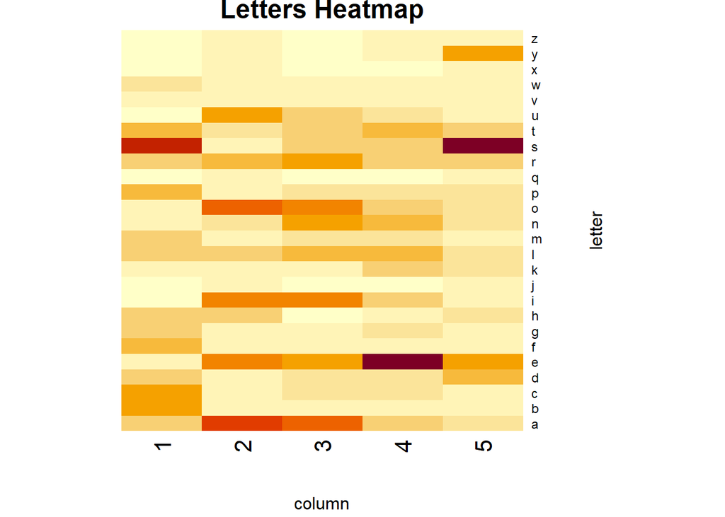

```r
heatmap(letter_freq_dict, Colv = NA, Rowv = NA, scale = "column", xlab = "column", ylab = "letter", main = "Letters Heatmap")
```

Do you see major differences between the two tables? why? Yes, there is a big difference since in moby dick there are way more words then in the most common 5 letter word’s in the english dictionry. There fore there are many more words in the moby dick book.

Also there is a difference in the heat map:

We can see that We can see that for the- first location:s second location:a third location:a fourth location:e fifth location:s

compared to question 4: first location:w second location:h third location:a fourth location:e fifth location:e

### *b*

Write a function that receives an array of guess words, an array of their corresponding matches to the unknown word (i.e. a two-dimensional array), and a `disctionary` - i.e. an array of legal English words. The function should return all the words in the dictionary that are consistent with the results of the previous guesses. For example, if we guessed `maple` and our match was the array `[1, 0, -1, 0, 0]`, then we should keep only words that start with an `m`, have a `p` at a location different from $3$, and don’t have `a`, `l` and `e`. When we have multiple guesses, our list of consistent words should be consistent with all of them, hence as we add more guesses, the list of consistent words will become shorter and shorter.  
Run your function on the list of words from (a.), and with the guesses `c("south", "north")` and their corresponding matches: `c(-1, 1, 1, 0, 0)` and `c(0, 1, 0, 0, 0)`. Output the list of consistent words with these two guesses.

```r
#help function for dictionary- make in to a data frame
data_dict2 = function(dictionary){
  words_vec = dictionary
  df <- data.frame(words_vec)
  df[c(1:5)]<- str_split_fixed(df$words_vec,"",5)
  df <- df[c(1:5)]
  return(df)
}

Wordle = function(geuss,matching,dictionary){
  dictionary = data_dict2(dictionary)
  for (i in 1:length(geuss)){
    for (j in 1:5){
        if (matching[j + (i-1) *5] == 0) {
        geuss_word <- as.vector(str_split_fixed(geuss[i], pattern = "", n = nchar(geuss[i])))

        dictionary <- subset(dictionary, (dictionary[1]!=geuss_word[j]) &
                                         (dictionary[2]!=geuss_word[j]) &
                                         (dictionary[3]!=geuss_word[j]) &
                                         (dictionary[4]!=geuss_word[j]) &
                                         (dictionary[5]!=geuss_word[j]))

        } else if (matching[j + (i-1) *5] == -1){
        geuss_word <- as.vector(str_split_fixed(geuss[i], pattern = "", n = nchar(geuss[i])))
                dictionary <- subset(dictionary, dictionary[1]==geuss_word[j] |
                                         dictionary[2]==geuss_word[j] |
                                         dictionary[3]==geuss_word[j] |
                                         dictionary[4]==geuss_word[j] |
                                         dictionary[5]==geuss_word[j])

        dictionary <- subset(dictionary,dictionary[j]!=geuss_word[j])

        } else {
        geuss_word <- as.vector(str_split_fixed(geuss[i], pattern = "", n = nchar(geuss[i])))
        dictionary <- subset(dictionary,dictionary[j]==geuss_word[j])
        }
    }
  }
dictionary <- na.omit(dictionary)
df <- c(dictionary, sep = "")
result <- do.call(paste,df)
return(result)
}

geuss = c("south", "north")
check = Wordle(geuss,c(c(-1, 1, 1, 0, 0), c(0, 1, 0, 0, 0)),words_string)
check
```

```
##  [1] "mouse" "lousy" "louse" "fouls" "douse" "louis" "coups" "mousy" "poufs"
## [10] "youse"
```

## **Question 6**

### *a*

*strategy 1*

Implement a function that receives as input the unknown word, and implements this strategy. The output should be the number of turns it took to guess the word. The function should also record and print guess at each turn, as well as the match array , until the word is guessed correctly.  
Run the function when the unknown word is “mouse”, and show the results.

```r
set.seed(1)
strategy_one = function(unknown,tn=TRUE){
  # splitting unknown word into 5 letters
  unknown_word = as.vector(str_split_fixed(unknown, pattern = "", n = nchar(unknown)))
  # guessing 5 random letters
  guesses = c(sample(letters, 1),sample(letters, 1),sample(letters, 1),sample(letters, 1),sample(letters, 1))
  #counter for amount of times the function runs until correct word is guessed
  guess_count = 1
  while (!(identical(unknown_word,guesses)==TRUE)){
      guess_array = c()
      guess_count = guess_count + 1
  for (i in 1:5){
      if(isTRUE(unknown_word[i]==guesses[i])==TRUE){
        guess_array[i] = 1
        }
      else{
        guess_array[i] = 0
        guesses[i] = sample(letters, 1)
      }
    guessed_word = str_c(guesses,collapse="")
    guessed_array = str_c(guess_array,collapse="")
  }

if (tn==TRUE){
        print(cbind(guessed_word,guessed_array))

      }  }
  return (guess_count)
}

strategy_one_try = strategy_one("mouse")
```

```
##      guessed_word guessed_array
## [1,] "wknrs"      "00000"
##      guessed_word guessed_array
## [1,] "auujv"      "00000"
##      guessed_word guessed_array
## [1,] "njugi"      "00100"
##      guessed_word guessed_array
## [1,] "ouuei"      "00100"
##      guessed_word guessed_array
## [1,] "ynuee"      "00100"
##      guessed_word guessed_array
## [1,] "bjuye"      "00101"
##      guessed_word guessed_array
## [1,] "louae"      "00101"
##      guessed_word guessed_array
## [1,] "touce"      "01101"
##      guessed_word guessed_array
## [1,] "fouje"      "01101"
##      guessed_word guessed_array
## [1,] "joufe"      "01101"
##      guessed_word guessed_array
## [1,] "ooute"      "01101"
##      guessed_word guessed_array
## [1,] "touze"      "01101"
##      guessed_word guessed_array
## [1,] "louye"      "01101"
##      guessed_word guessed_array
## [1,] "woufe"      "01101"
##      guessed_word guessed_array
## [1,] "youhe"      "01101"
##      guessed_word guessed_array
## [1,] "louye"      "01101"
##      guessed_word guessed_array
## [1,] "wouxe"      "01101"
##      guessed_word guessed_array
## [1,] "fouze"      "01101"
##      guessed_word guessed_array
## [1,] "gouse"      "01101"
##      guessed_word guessed_array
## [1,] "jouse"      "01111"
##      guessed_word guessed_array
## [1,] "fouse"      "01111"
##      guessed_word guessed_array
## [1,] "xouse"      "01111"
##      guessed_word guessed_array
## [1,] "nouse"      "01111"
##      guessed_word guessed_array
## [1,] "bouse"      "01111"
##      guessed_word guessed_array
## [1,] "mouse"      "01111"
```

```r
strategy_one_try
```

```
## [1] 26
```

### *b*

Write a mathematical formula for the distribution of the number of turns needed to guess the target word with this strategy.

The Geomertrical distribution is:
$$Pr(X=k)=(1-p)^{k-1}p$$
Cumulitive Geomertrical distribution is:
$$Pr(X ≤ x) = 1 - (1 - p)^{x}$$
Because each letter is iid the intersection is the multipication of each letters geometric distribution, there-fore the probability of geussing at or before x is the probability of each letter geussing at less than x or on x. therefore:

$$Pr(X <= x) = Pr(X ≤ x)∩Pr(X ≤ x) ... ∩Pr(X ≤ x) = Pr(X ≤ x)*Pr(X ≤ x) ... *Pr(X ≤ x)$$
By calculating this we will get:
$$Pr(X ≤ x)*Pr(X ≤ x) ... *Pr(X ≤ x) = 1 - (1 - p)^{x} * 1 - (1 - p)^{x} ... 1 - (1 - p)^{x}$$
$$1 - (1 - p)^{x} * 1 - (1 - p)^{x}*1 - (1 - p)^{x}* 1 - (1 - p)^{x}*1 - (1 - p)^{x} = {(1 - (1 - p)^{x})}^{n}$$
By the identity we get that:
$$P(X=x)=P(X≤x)−P(X≤x−1)⇒P(X=x)={[{1−(1−p)}^x]}^n−{[{1−(1−p)}^{x-1}]}^n$$
We know the chance of each letter is uniform from 26 letter’s, therefore:
$$p=1/26$$
We will continue by calculating:
$$P(X=x)={[{1−(1−1/26)}^x]}^n−{[{1−(1−1/26)}^{x-1}]}^n$$
By definition
$$E(x)$$
is:

$$E(x) = \sum_{i=1}^{x=10000}x*Pr(X=x)$$
A function that will calculate the expectaion E(x) is-

```r
expec_func <- function(x){
  p <- 1/26
  n <- 5
  expec = 0
  for (i in 1:10000){
    dist <- (1-(1-p)^i)^n - (1-(1-p)^(i-1))^n
    expectation = dist*i
    expec = expec + expectation}
  print(expec)
}
expectation_X = expec_func(10000)
```

```
## [1] 58.71754
```

```r
expectation_X
```

```
## [1] 58.71754
```

### *c*

Compute empirically the distribution of the number of turns using the following Monte-Carlo simulation: - Draw $B=100$ random unknown words, uniformly at random from the list of five-letter words in Qu. 5. - For each unknown word, run the guessing strategy implemented in (a.) and record the number of turns - Compute the average number of turns across all $B=100$ simulations.

```r
set.seed(1)
sampled_word = sample(words_string,1)
monte_carlo <-replicate(100,strategy_one(sampled_word,tn=FALSE))
mean(monte_carlo)
```

```
## [1] 58.15
```

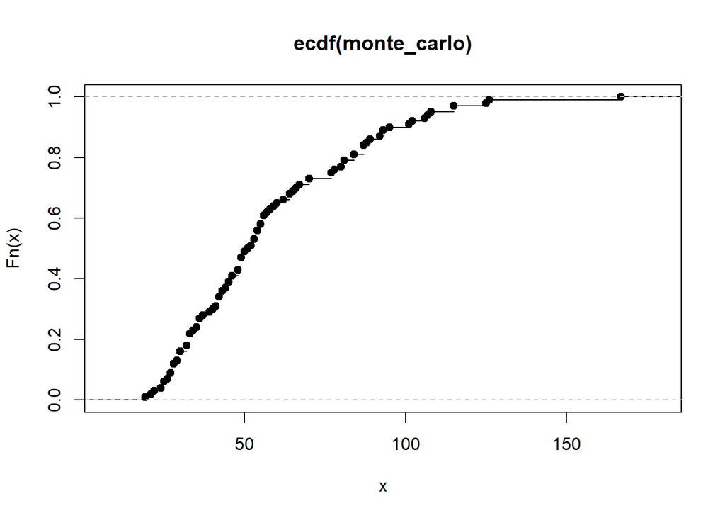

```r
plot(ecdf(monte_carlo))
```

```r
points <- seq(1:100)
```

compare also the empirical expectation with the expectation computed in (b) How close are they? in b - 58.71754 in c -58.15 they are very close as we can see

## **Question 7**

### *a*

Implement the following two additional strategies for guessing the word: Run both strategies with the unknown word “mouse”, and show the guesses and the number of turns for them, in similar to Qu. 6.a.

```r
# Helper function:
wordle_match <- function(guess, word)  # 1: correct location, -1: wrong location, 0: missing
{
  L <- nchar(guess)
  match <- rep(0, L)
  for(i in 1:L)
  {
    if(grepl(substr(guess, i, i), word, fixed=TRUE))
      {match[i] = -1}
    if(substr(guess, i, i) == substr(word, i, i))
    {      match[i] = 1}
  }

  return(match)
}
```

*Strategy 2*

At each stage, we guess the word with the highest likelihood (see Qu. 4.c.), of the remaining words that are consistent with the previous guesses. - We keep guessing until obtaining the correct word.

```r
strat2 = function(word_list, unknown_word,if_print=TRUE){
  #convertng unknown to a string of letters
  unknown_word_2 = as.vector(str_split_fixed(unknown_word, pattern = "", n = nchar(unknown_word)))
  #using 4 in order to find freq of words_string and find the starting word
  wordle_freq <- table(let = unlist(strsplit(word_list,'')),pos = sequence(nchar(word_list)))
wordle_prob = wordle_freq/(length(word_list))
frequency_words = probabilities(wordle_prob,word_list)
picked_word<- sort(frequency_words , decreasing = TRUE)[1]
picked_word <- names(picked_word)

new_df <- word_list
counter = 0
# as long as the correct word has not been guessed
  while (!identical(picked_word,unknown_word)){
  vec_array = wordle_match(picked_word, unknown_word)

#Create new dictionary using 5b
new_df = Wordle(picked_word,vec_array,new_df)

#choosing new word
wordle_freq <- table(let = unlist(strsplit(new_df,'')),pos = sequence(nchar(new_df)))
wordle_prob = wordle_freq/(length(new_df))
frequency_words = probabilities(wordle_prob,new_df)
picked_word<- sort(frequency_words , decreasing = TRUE)[1]
picked_word <- names(picked_word)
counter = counter +1
if(if_print == TRUE){
  print(picked_word)
}
  }
  print(counter)
}

unknown_word <- "mouse"
a_df <- strat2(words_string, unknown_word,if_print=TRUE)
```

```
## [1] "place"
## [1] "sense"
## [1] "mouse"
## [1] 3
```

```r
a_df
```

```
## [1] 3
```

*Strategy 3*

The same as strategy 2, but at each stage we guess a random word sampled uniformly from all remaining consistent words (instead of guessing the word with the highest likelihood).

```r
strat3 = function(word_list, unknown_word,if_print=TRUE){
  picked_word = sample(word_list,1)
  #using 4 in order to find freq of words_string and find the starting word

new_df <- word_list
counter = 0
  while (!identical(picked_word,unknown_word)){
  vec_array = wordle_match(picked_word, unknown_word)

#Create new dictionary using 5b
new_df = Wordle(picked_word,vec_array,new_df)

#choosing new word
  picked_word = sample(word_list,1)
  counter = counter +1
  if(if_print == TRUE){

  print(picked_word)
}
  }
  print(counter)
  }

unknown_word <- "mouse"
strat3(words_string, unknown_word,if_print = TRUE)
```

```
## [1] "fries"
## [1] "gloat"
## [1] "plyer"
## [1] "lucid"
## [1] "avast"
## [1] "freer"
## [1] "clunk"
## [1] "sates"
## [1] "while"
## [1] "withs"
## [1] "goest"
## [1] "lisps"
## [1] "geeks"
## [1] "hopes"
## [1] "steno"
```

[output cut: 6880 more lines]

### *b*

Run $B = 100$ simulations of the games, in similar to Qu. 6.c. That is, each time, sample a random unknown word, run the two strategies $2$ and $3$, and record the number of turns needed to solve `wordle` for both of them.

- Plot the empirical CDFs of the number of guesses. How similar are they to each other? how similar are they to the CDF of strategy 1? What are the empirical means for both strategies?

*Strategy 2 and 3 simulation*

```r
random_words = sample(words_string,100,replace = TRUE)
strat2_tries=sapply(random_words,function(new_word){strat2(words_string,new_word,if_print=FALSE)})
```

```
## [1] 3
## [1] 2
## [1] 6
## [1] 6
## [1] 3
## [1] 3
## [1] 4
## [1] 6
## [1] 4
## [1] 4
## [1] 8
## [1] 3
## [1] 3
## [1] 5
## [1] 6
```

[output cut: 85 more lines]

```r
strat3_tries=sapply(random_words,function(new_word){strat3(words_string,new_word,if_print=FALSE)})
```

```
## [1] 10114
## [1] 7650
## [1] 8485
## [1] 1434
## [1] 5783
## [1] 6605
## [1] 171
## [1] 6550
## [1] 6211
## [1] 468
## [1] 5228
## [1] 20171
## [1] 2515
## [1] 2352
## [1] 2540
```

[output cut: 85 more lines]

```r
print(mean(strat2_tries))
```

```
## [1] 3.86
```

```r
print(mean(strat3_tries))
```

```
## [1] 6313.8
```

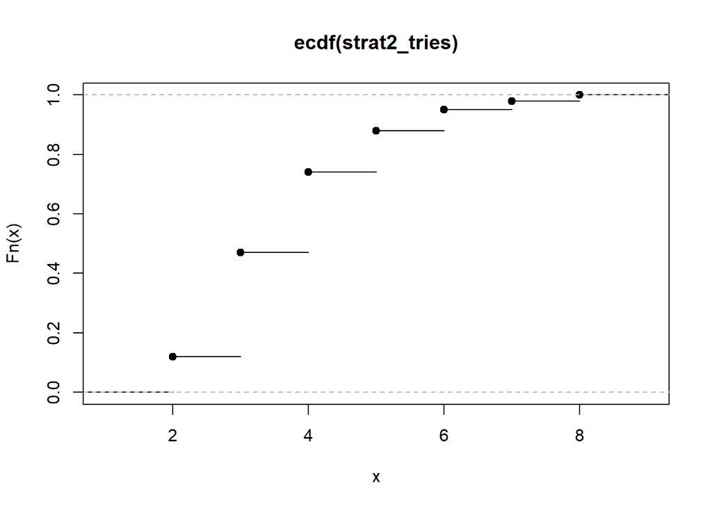

```r
plot(ecdf(strat2_tries))
```

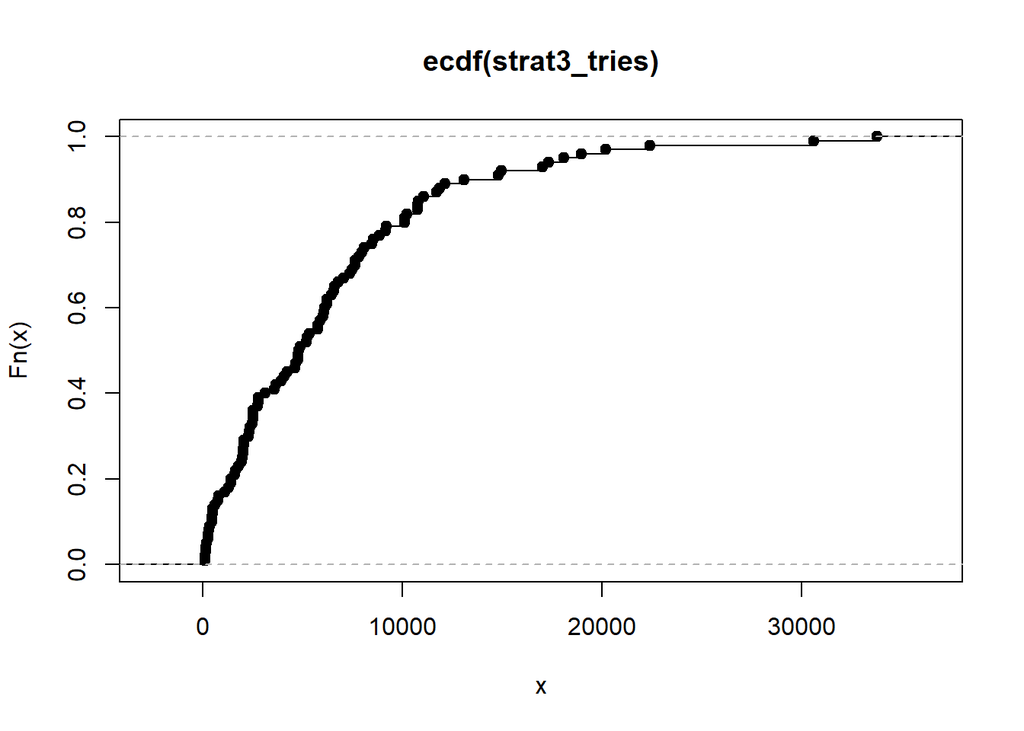

```r
plot(ecdf(strat3_tries))
```

The empirical mean of strategy 2 is 3.86 and of strategy 3 is 6313.8. This is a huge difference since strategy 3 is not at all efficient. We can see this from the ecdf too since strategy 3 has many many rotations until a successful guess, as seen in the graph. On the other hand strategy 2 is very efficient and will guess the correct word in approximately 4 turns!